# Prob 4 CP 3: Suas análises

## 2- A popularidade das atividades de 2017 é maior doque de 2016? (medida estatística: Mediana)

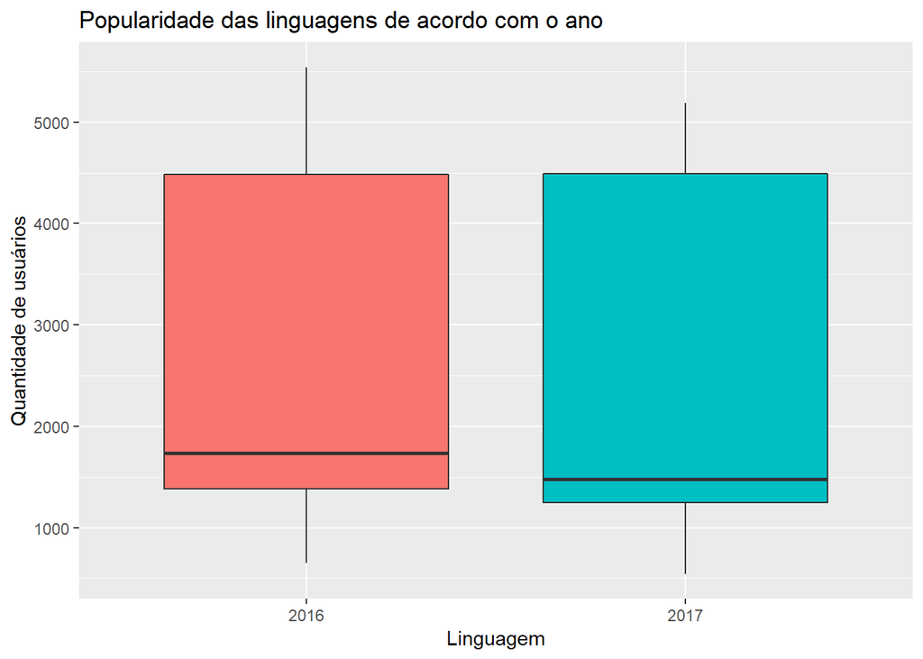

```r
linguagens %>% group_by(the_year) %>%
  ggplot(aes(x = the_year,
             y = users,
             fill=the_year)) +
  geom_boxplot() +
  ggtitle("Popularidade das linguagens de acordo com o ano") +
  labs(x = "Linguagem", y = 'Quantidade de usuários') +
  theme(legend.position="none")
```

Analisando rapidamente esse boxploto dos dados de popularidade de acordo com o ano, parece não ter muita diferença na popularidade de um para o outro.

Fazendo o bootstrap de acordo com o ano de 2016.

```r
median.2016 = linguagens%>%
  filter(the_year==2016) %>%
  bootstrap(median(users),
            R = 5000) %>%
    CI.percentile(probs = c(.025, .975))
median.2016
```

```
##               2.5% 97.5%
## median(users) 1680  2390
```

Fazendo o bootstrap de acordo com o ano de 2017.

```r
median.2017 = linguagens%>%
  filter(the_year==2017) %>%
  bootstrap(median(users),
            R = 5000) %>%
    CI.percentile(probs = c(.025, .975))
median.2017
```

```
##               2.5% 97.5%
## median(users) 1338  2705
```

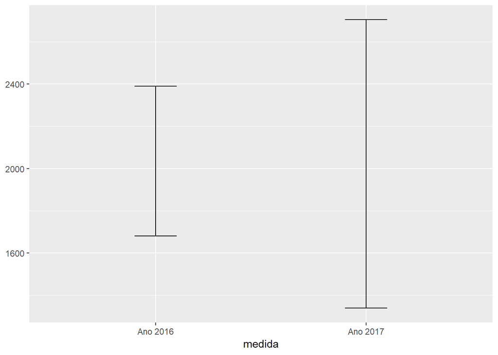

```r
df = data.frame(rbind(median.2016,
                      median.2017
                      ))
df$medida = c('Ano 2016', 'Ano 2017')

df %>%
  ggplot(aes(x = medida, ymin = X2.5., ymax = X97.5.)) +
  geom_errorbar(width = .2)
```

Como a intercesção dos intervalos não tem como dizer se um ano foi mais popular doque o outro, mas provavelmente não.

## Python é o tipo de arquivo mais popular, ou pelo menos a linguagem mais popular?

Como python teve uma vantagem muito grande em popularidade em relação a linguagem c(outra linguagem bem consolidade e popular entre os programadores), fez-me pensar se ela não seria a linguagem mais popular.

Fazendo a media de popularidade por arquivo e ordenando de forma descrescente, vemos que nos dados a linguagem python fica em 5º lugar entre os arquivos e 2º em linguagem de programação, já que md json e html não são linguagens de programação.

```r
lmp <- github %>% group_by(file_extension) %>% summarise(Popularidade = mean(users))
arrange(lmp,desc(Popularidade))
```

```
## # A tibble: 42 x 2
##    file_extension Popularidade
##    <chr>                 <dbl>
##  1 md                    7657.
##  2 js                    6225.
##  3 json                  4417.
##  4 html                  4110.
##  5 py                    4042.
##  6 java                  3134.
##  7 css                   2584.
##  8 xml                   2526.
##  9 txt                   2509.
## 10 yml                   2253.
## # ... with 32 more rows
```

```r
head(lmp)
```

```
## # A tibble: 6 x 2
##   file_extension Popularidade
##   <chr>                 <dbl>
## 1 c                     1270.
## 2 cc                     519.
## 3 config                 512.
## 4 cpp                   1660.
## 5 cs                    1095.
## 6 csproj                 626.
```

Em média de popularidade vemos que o arquivo de extensão mais popular nessa amostra é md, seguida de js. Python está em quinto nessa lista.

Agora pegando esses 2 primeiros arquivos e python, vamo fazer o intervalo para saber se isso mesmo se confirma.

```r
median.py = github%>%
  filter(file_extension=="py") %>%
  bootstrap(median(users),
            R = 5000) %>%
    CI.percentile(probs = c(.025, .975))
median.py
```

```
##                   2.5% 97.5%
## median(users) 4411.527  4580
```

```r
median.md = github%>%
  filter(file_extension=="md") %>%
  bootstrap(median(users),
            R = 5000) %>%
    CI.percentile(probs = c(.025, .975))
median.md
```

```
##                   2.5% 97.5%
## median(users) 7938.116  8331
```

```r
median.js = github%>%
  filter(file_extension=="js") %>%
  bootstrap(median(users),
            R = 5000) %>%
    CI.percentile(probs = c(.025, .975))
median.js
```

```
##               2.5% 97.5%
## median(users) 6641  6876
```

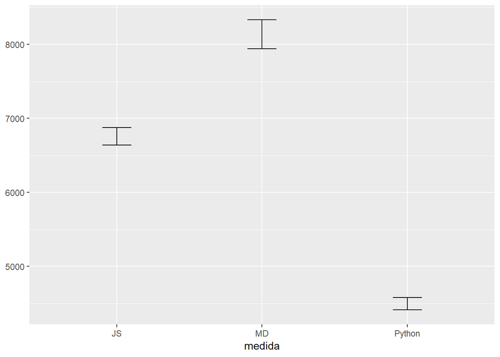

```r
df = data.frame(rbind(median.py,
                      median.md,
                      median.js

                      ))
df$medida = c('Python', 'MD', 'JS')

df %>%
  ggplot(aes(x = medida, ymin = X2.5., ymax = X97.5.)) +
  geom_errorbar(width = .2)
```

Como podemos ver não a intersecção de valores dos intervalores, logo python não está nem em segundo nessa lista, e podemos ainda afirmar que md é o arquivo de extensão mais popular no github entre os anos de 2016 e 2017. Como javaScrpit também teve uma vantagem maior que python, podemos também dizer que entres as linguagens de programação javaScript é a mais popular.

Outra pergunta que pode ser feita é em relação aos dias da semana

## 4-Qual o dia de semana mais popular entre os tipos de arquivos?

```r
median.m = github%>%
  filter(day=="Monday") %>%
  bootstrap(median(users),
            R = 5000) %>%
    CI.percentile(probs = c(.025, .975))
median.m
```

```
##                 2.5% 97.5%
## median(users) 1424.5  1633
```

```r
median.t = github%>%
  filter(day=="Tuesday") %>%
  bootstrap(median(users),
            R = 5000) %>%
    CI.percentile(probs = c(.025, .975))
median.t
```

```
##                 2.5%    97.5%
## median(users) 1416.5 1612.227
```

```r
median.w = github%>%
  filter(day=="Wednesday") %>%
  bootstrap(median(users),
            R = 5000) %>%
    CI.percentile(probs = c(.025, .975))
median.w
```

```
##               2.5% 97.5%
## median(users) 1406  1631
```

```r
median.th = github%>%
  filter(day=="Thursday") %>%
  bootstrap(median(users),
            R = 5000) %>%
    CI.percentile(probs = c(.025, .975))
median.th
```

```
##               2.5% 97.5%
## median(users) 1387  1636
```

```r
median.f = github%>%
  filter(day=="Friday") %>%
  bootstrap(median(users),
            R = 5000) %>%
    CI.percentile(probs = c(.025, .975))
median.f
```

```
##               2.5% 97.5%
## median(users) 1415  1626
```

```r
median.sa = github%>%
  filter(day=="Saturday") %>%
  bootstrap(median(users),
            R = 5000) %>%
    CI.percentile(probs = c(.025, .975))
median.sa
```

```
##                 2.5% 97.5%
## median(users) 1400.5  1599
```

```r
median.su = github%>%
  filter(day=="Sunday") %>%
  bootstrap(median(users),
            R = 5000) %>%
    CI.percentile(probs = c(.025, .975))
median.su
```

```
##                 2.5% 97.5%
## median(users) 1399.5  1617
```

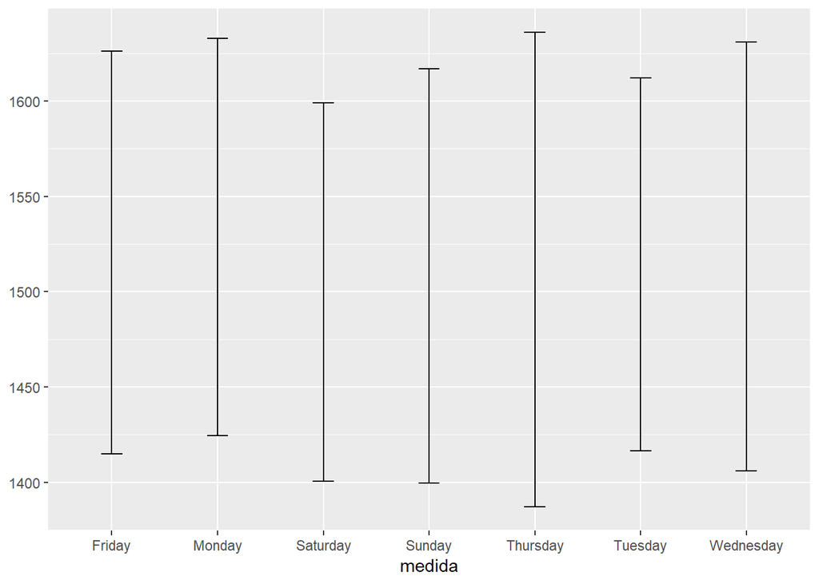

```r
df = data.frame(rbind(median.m,
                      median.t,
                      median.w,
                      median.th,
                      median.f,
                      median.sa,
                      median.su

                      ))
df$medida = c('Monday', 'Tuesday', 'Wednesday', 'Thursday', 'Friday', 'Saturday', 'Sunday')

df %>%
  ggplot(aes(x = medida, ymin = X2.5., ymax = X97.5.)) +
  geom_errorbar(width = .2)
```

Não parece ter dia mais popular todos estão em uma certa faixa de valores, não podemos então afirmar nada com certeza. A resposta é: Não sei dizer se tem alguma dia mais popular doque os outros, mas provavelmente não.

Se o dia não importa será que os meses então influenciam na popularidade?

## 5-A proporção de produtividade dos usuários é maior no inicio ou final do ano?

Tratando o inicío do ano como sendo os três primeiros meses e o resto como sendo o final do ano.

```r
mmp <- github %>% group_by(the_month) %>% summarise(Popularidade = mean(users))
arrange(mmp,desc(Popularidade))
```

```
## # A tibble: 12 x 2
##    the_month Popularidade
##    <chr>            <dbl>
##  1 2                2258.
##  2 3                2245.
##  3 1                2199.
##  4 6                2196.
##  5 11               2158.
##  6 10               2124.
##  7 4                2095.
##  8 12               2074.
##  9 9                2072.
## 10 8                2067.
## 11 5                2065.
## 12 7                2051.
```

```r
github <- github %>% mutate (
              inicio_ano = case_when(
      (the_month == 1 | the_month == 2 | the_month == 3  ) ~ TRUE,
      TRUE~FALSE

    ))

median.ini = github%>%
  filter(inicio_ano) %>%
  bootstrap(median(users),
            R = 5000) %>%
    CI.percentile(probs = c(.025, .975))
median.ini
```

```
##                   2.5% 97.5%
## median(users) 1487.838  1680
```

```r
median.rest = github%>%
  filter(!inicio_ano) %>%
  bootstrap(median(users),
            R = 5000) %>%
    CI.percentile(probs = c(.025, .975))
median.rest
```

```
##               2.5% 97.5%
## median(users) 1445  1535
```

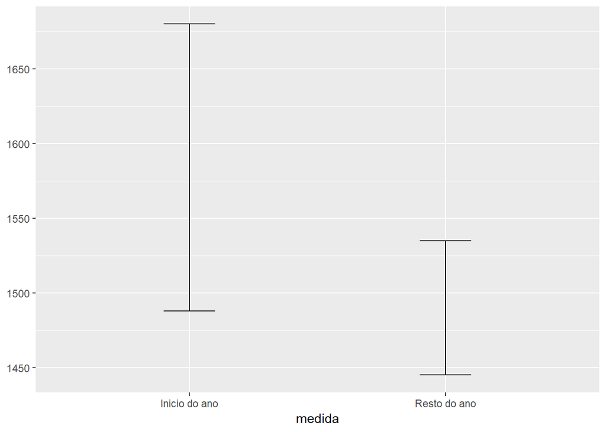

```r
df = data.frame(rbind(median.ini,
                      median.rest

                      ))
df$medida = c('Inicio do ano', 'Resto do ano')

df %>%
  ggplot(aes(x = medida, ymin = X2.5., ymax = X97.5.)) +
  geom_errorbar(width = .2)
```

Como observamos acima parece haver sim uma popularidade maior no início do ano mais doque no final, mas não da pra afirmar com uma certa certeza, pos existe uma intersecção entre os intervalos. Seria interessante busca a causa disso será que é porque os meses de férias nos Estados unidos fica geralmente no meio do ano? Ou seria por feriados?

Com essa simples e curta análise podemos responder algumas dúvidas e perguntas que poderiamos ter sobre os dados, é interessante buscar questões como essa e depois tentar descobrir a causa de tais respostas.